# IODS course project

#Hypothesis 3. Amount of going out is correlated with higher alcohol use

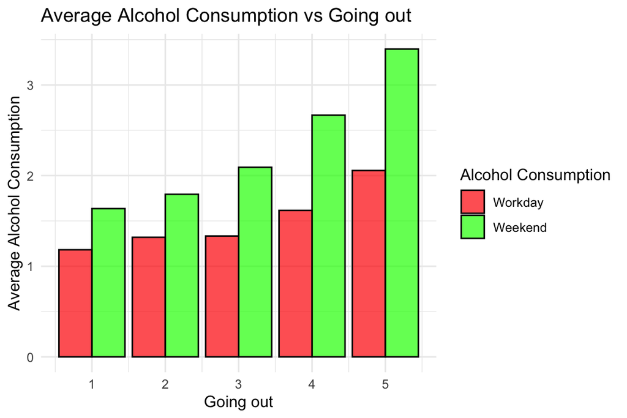

```r
gathered_data <- alc_data %>%
  gather(key = "variable", value = "alcohol_consumption", Dalc, Walc)

ggplot(gathered_data, aes(x = goout, fill = variable, y = alcohol_consumption)) +
  geom_bar(position = "dodge", stat = "summary", fun = "mean", color = "black", alpha = 0.7) +
  labs(title = "Average Alcohol Consumption vs Going out",
       x = "Going out",
       y = "Average Alcohol Consumption") +
  scale_fill_manual(values = c("red", "green"), name = "Alcohol Consumption",
                    labels = c("Workday", "Weekend")) +
  theme_minimal()
```

```r
logistic_model <- glm(high_use ~ Dalc + Walc + goout,
                      data = alc_data,
                      family = binomial,
                      maxit = 1000)
summary(logistic_model)
```

```
##
## Call:
## glm(formula = high_use ~ Dalc + Walc + goout, family = binomial,
##     data = alc_data, maxit = 1000)
##
## Coefficients:
##               Estimate Std. Error z value Pr(>|z|)
## (Intercept) -2.434e+02  4.263e+05  -0.001        1
## Dalc         5.424e+01  1.121e+05   0.000        1
## Walc         5.399e+01  9.967e+04   0.001        1
## goout       -1.091e-03  4.686e+04   0.000        1
##
## (Dispersion parameter for binomial family taken to be 1)
##
##     Null deviance: 4.5204e+02  on 369  degrees of freedom
## Residual deviance: 3.4654e-10  on 366  degrees of freedom
## AIC: 8
##
## Number of Fisher Scoring iterations: 29
```

```r
odds_ratios <- exp(coef(logistic_model))
conf_intervals <- exp(confint(logistic_model))
cat("\nOdds Ratios and 95% Confidence Intervals:\n")
```

```
##
## Odds Ratios and 95% Confidence Intervals:
```

```r
data.frame(Odds_Ratio = odds_ratios,
           Lower_CI = conf_intervals[, 1],
           Upper_CI = conf_intervals[, 2])
```

```
##                Odds_Ratio Lower_CI Upper_CI
## (Intercept) 1.980652e-106        0        0
## Dalc         3.582535e+23        0      Inf
## Walc         2.813755e+23        0      Inf
## goout        9.989097e-01       NA      Inf
```

#Hypothesis 4. increased internet usage is correlated with smaller alcohol consumption.

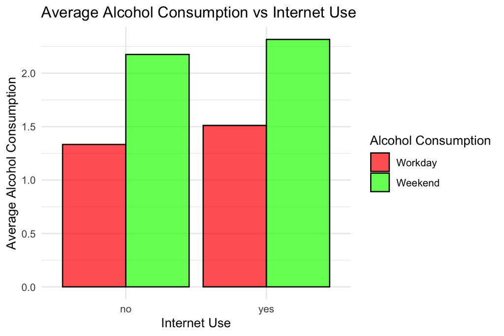

```r
gathered_data <- alc_data %>%
  gather(key = "variable", value = "alcohol_consumption", Dalc, Walc)

ggplot(gathered_data, aes(x = internet, fill = variable, y = alcohol_consumption)) +
  geom_bar(position = "dodge", stat = "summary", fun = "mean", color = "black", alpha = 0.7) +
  labs(title = "Average Alcohol Consumption vs Internet Use",
       x = "Internet Use",
       y = "Average Alcohol Consumption") +
  scale_fill_manual(values = c("red", "green"), name = "Alcohol Consumption",
                    labels = c("Workday", "Weekend")) +
  theme_minimal()
```

```r
logistic_model <- glm(high_use ~ Dalc + Walc + internet,
                      data = alc_data,
                      family = binomial,
                      maxit = 1000)
summary(logistic_model)
```

```
##
## Call:
## glm(formula = high_use ~ Dalc + Walc + internet, family = binomial,
##     data = alc_data, maxit = 1000)
##
## Coefficients:
##               Estimate Std. Error z value Pr(>|z|)
## (Intercept)   -243.506 429674.814  -0.001        1
## Dalc            54.231 112021.326   0.000        1
## Walc            53.991  97780.360   0.001        1
## internetyes      0.148 131720.810   0.000        1
##
## (Dispersion parameter for binomial family taken to be 1)
##
##     Null deviance: 4.5204e+02  on 369  degrees of freedom
## Residual deviance: 3.4659e-10  on 366  degrees of freedom
## AIC: 8
##
## Number of Fisher Scoring iterations: 29
```

```r
odds_ratios <- exp(coef(logistic_model))
conf_intervals <- exp(confint(logistic_model))
```

[output not shown]

```r
cat("\nOdds Ratios and 95% Confidence Intervals:\n")
```

```
##
## Odds Ratios and 95% Confidence Intervals:
```

```r
data.frame(Odds_Ratio = odds_ratios,
           Lower_CI = conf_intervals[, 1],
           Upper_CI = conf_intervals[, 2])
```

```
##                Odds_Ratio Lower_CI Upper_CI
## (Intercept) 1.764963e-106        0        0
## Dalc         3.566017e+23        0      Inf
## Walc         2.804818e+23      Inf      Inf
## internetyes  1.159493e+00       NA      Inf
```

#In the last section we do a prediction power model vs simple guessing of the results.

```r
predictions <- predict(logistic_model, type = "response") > 0.5

conf_matrix <- table(Actual = alc_data$high_use, Predicted = predictions)

print(conf_matrix)
```

```
##        Predicted
## Actual  FALSE TRUE
##   FALSE   259    0
##   TRUE      0  111
```

```r
training_error <- sum(alc_data$high_use != predictions) / nrow(alc_data)
cat("\nTraining Error:", training_error, "\n")
```

```
##
## Training Error: 0
```

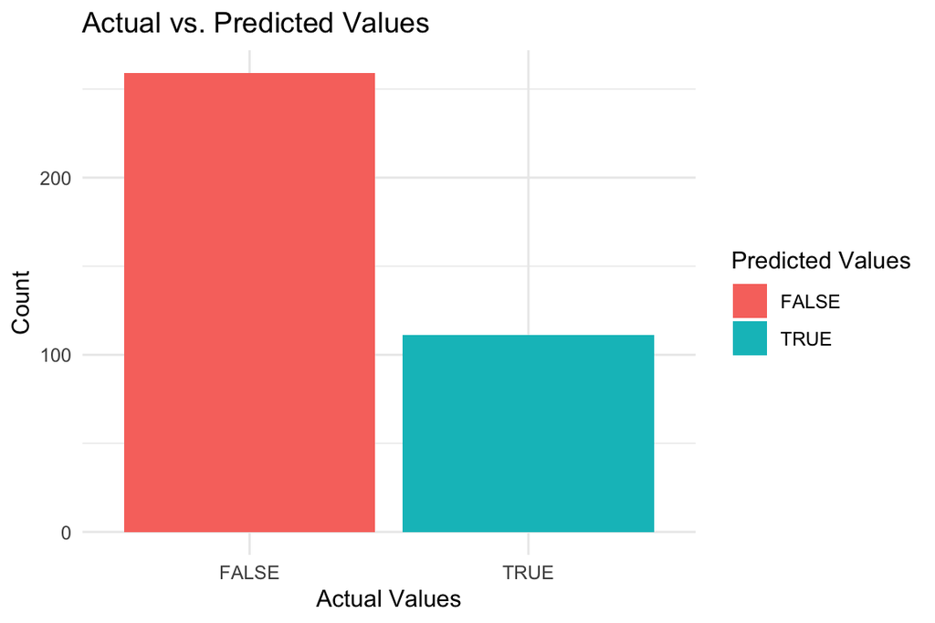

```r
library(ggplot2)
ggplot(alc_data, aes(x = as.factor(high_use), fill = as.factor(predictions))) +
  geom_bar(position = "dodge") +
  labs(title = "Actual vs. Predicted Values",
       x = "Actual Values",
       y = "Count",
       fill = "Predicted Values") +
  theme_minimal()
```

```r
training_error <- sum(alc_data$high_use != predictions) / nrow(alc_data)
cat("\nTraining Error:", training_error, "\n")
```

```
##
## Training Error: 0
```

```r
majority_class <- as.numeric(names(sort(table(alc_data$high_use), decreasing = TRUE)[1]))
simple_guess_predictions <- rep(majority_class, nrow(alc_data))


model_accuracy <- sum(alc_data$high_use == predictions) / nrow(alc_data)


simple_guess_accuracy <- sum(alc_data$high_use == simple_guess_predictions) / nrow(alc_data)

cat("Model Accuracy:", model_accuracy, "\n")
```

```
## Model Accuracy: 1
```

```r
cat("Simple Guessing Accuracy:", simple_guess_accuracy, "\n")
```

```
## Simple Guessing Accuracy: NA
```

The model has 100% success rate and no false results. There are also 0 incorrectly typed individuals.

#Bonus I

```r
library(caret)
alc_data$high_use <- as.factor(alc_data$high_use)

set.seed(123)

ctrl <- trainControl(method = "cv", number = 10)

cv_model <- train(high_use ~ Dalc + Walc + romantic, data = alc_data, method = "glm", family = binomial, trControl = ctrl)
print(cv_model)
```

```
## Generalized Linear Model
##
## 370 samples
##   3 predictor
##   2 classes: 'FALSE', 'TRUE'
##
## No pre-processing
## Resampling: Cross-Validated (10 fold)
## Summary of sample sizes: 333, 333, 333, 333, 333, 333, ...
## Resampling results:
##
##   Accuracy  Kappa
##   1         1
```

```r
previous_model_error <- 0.26

cv_model_error <- 1 - cv_model$results$Accuracy

cat("\nPrevious Model Error:", previous_model_error, "\n")
```

```
##
## Previous Model Error: 0.26
```

```r
cat("Cross-Validation Model Error:", mean(cv_model_error), "\n")
```

```
## Cross-Validation Model Error: 0
```

Bonus I: Performing a 10 fold cross validation and checking the test performance.

#Assignment 4

The dataset used for this weeks assignment describes the housing values in Suburbs of Boston. The set is shown below. The meaning of the factors are as follows:crim = per capita crime rate by town, zn = proportion of residential land zoned for lots over 25,000 sq.ft., indus = proportion of non-retail business acres per town, chas = Charles River dummy variable (= 1 if tract bounds river; 0 otherwise), nox = nitrogen oxides concentration (parts per 10 million), rm = average number of rooms per dwelling, age = proportion of owner-occupied units built prior to 1940, dis = weighted mean of distances to five Boston employment centres, rad = index of accessibility to radial highways, tax = full-value property-tax rate per $10,000, ptratio = pupil-teacher ratio by town, black = 1000(Bk−0.63)^2 where Bk is the proportion of blacks by town, lstat = lower status of the population (percent), medv = median value of owner-occupied homes in $1000s

```r
library(MASS)
data(Boston)
str(Boston)
```

```
## 'data.frame':    506 obs. of  14 variables:
##  $ crim   : num  0.00632 0.02731 0.02729 0.03237 0.06905 ...
##  $ zn     : num  18 0 0 0 0 0 12.5 12.5 12.5 12.5 ...
##  $ indus  : num  2.31 7.07 7.07 2.18 2.18 2.18 7.87 7.87 7.87 7.87 ...
##  $ chas   : int  0 0 0 0 0 0 0 0 0 0 ...
##  $ nox    : num  0.538 0.469 0.469 0.458 0.458 0.458 0.524 0.524 0.524 0.524 ...
##  $ rm     : num  6.58 6.42 7.18 7 7.15 ...
##  $ age    : num  65.2 78.9 61.1 45.8 54.2 58.7 66.6 96.1 100 85.9 ...
##  $ dis    : num  4.09 4.97 4.97 6.06 6.06 ...
##  $ rad    : int  1 2 2 3 3 3 5 5 5 5 ...
##  $ tax    : num  296 242 242 222 222 222 311 311 311 311 ...
##  $ ptratio: num  15.3 17.8 17.8 18.7 18.7 18.7 15.2 15.2 15.2 15.2 ...
##  $ black  : num  397 397 393 395 397 ...
##  $ lstat  : num  4.98 9.14 4.03 2.94 5.33 ...
##  $ medv   : num  24 21.6 34.7 33.4 36.2 28.7 22.9 27.1 16.5 18.9 ...
```

```r
dim(Boston)
```

```
## [1] 506  14
```

Showing a graphical overview of the data and correlations. It is used to predict the value of owner-occupied homes.

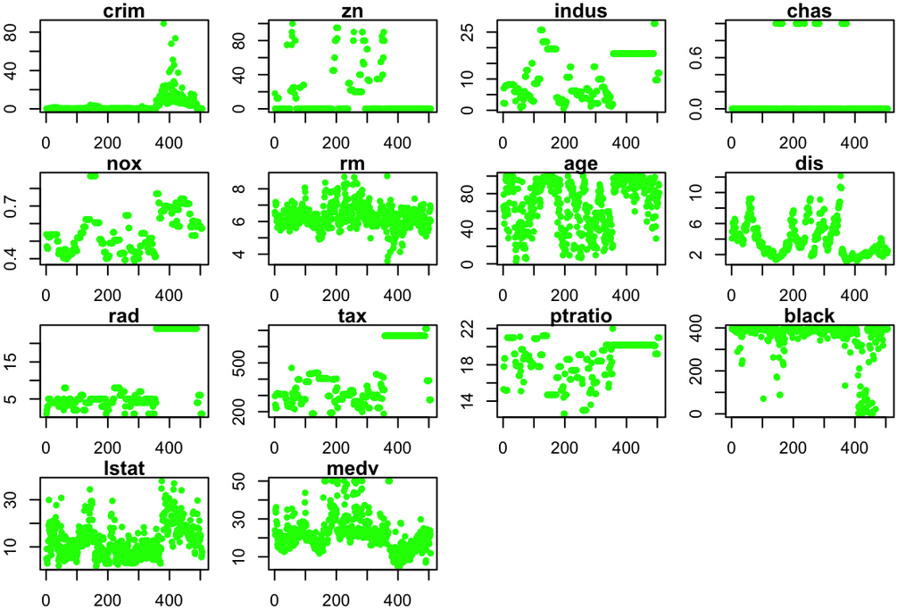

```r
par(mar = c(2, 2, 1, 1))
par(mfrow = c(4, 4))
for (i in 1:14) {
  plot(Boston[, i], main = names(Boston)[i], col = "green", pch = 20)
}
par(mfrow = c(1, 1))
```

```r
par(mar = c(5, 4, 4, 2) + 0.1)
```

# standardizing the data set and creating a training set.

```r
scaled_data <- as.data.frame(scale(Boston))

summary(scaled_data)
```

```
##       crim                 zn               indus              chas
##  Min.   :-0.419367   Min.   :-0.48724   Min.   :-1.5563   Min.   :-0.2723
##  1st Qu.:-0.410563   1st Qu.:-0.48724   1st Qu.:-0.8668   1st Qu.:-0.2723
##  Median :-0.390280   Median :-0.48724   Median :-0.2109   Median :-0.2723
##  Mean   : 0.000000   Mean   : 0.00000   Mean   : 0.0000   Mean   : 0.0000
##  3rd Qu.: 0.007389   3rd Qu.: 0.04872   3rd Qu.: 1.0150   3rd Qu.:-0.2723
##  Max.   : 9.924110   Max.   : 3.80047   Max.   : 2.4202   Max.   : 3.6648
##       nox                rm               age               dis
##  Min.   :-1.4644   Min.   :-3.8764   Min.   :-2.3331   Min.   :-1.2658
##  1st Qu.:-0.9121   1st Qu.:-0.5681   1st Qu.:-0.8366   1st Qu.:-0.8049
##  Median :-0.1441   Median :-0.1084   Median : 0.3171   Median :-0.2790
##  Mean   : 0.0000   Mean   : 0.0000   Mean   : 0.0000   Mean   : 0.0000
##  3rd Qu.: 0.5981   3rd Qu.: 0.4823   3rd Qu.: 0.9059   3rd Qu.: 0.6617
##  Max.   : 2.7296   Max.   : 3.5515   Max.   : 1.1164   Max.   : 3.9566
##       rad               tax             ptratio            black
##  Min.   :-0.9819   Min.   :-1.3127   Min.   :-2.7047   Min.   :-3.9033
##  1st Qu.:-0.6373   1st Qu.:-0.7668   1st Qu.:-0.4876   1st Qu.: 0.2049
##  Median :-0.5225   Median :-0.4642   Median : 0.2746   Median : 0.3808
##  Mean   : 0.0000   Mean   : 0.0000   Mean   : 0.0000   Mean   : 0.0000
##  3rd Qu.: 1.6596   3rd Qu.: 1.5294   3rd Qu.: 0.8058   3rd Qu.: 0.4332
##  Max.   : 1.6596   Max.   : 1.7964   Max.   : 1.6372   Max.   : 0.4406
##      lstat              medv
##  Min.   :-1.5296   Min.   :-1.9063
##  1st Qu.:-0.7986   1st Qu.:-0.5989
##  Median :-0.1811   Median :-0.1449
##  Mean   : 0.0000   Mean   : 0.0000
##  3rd Qu.: 0.6024   3rd Qu.: 0.2683
##  Max.   : 3.5453   Max.   : 2.9865
```

```r
scaled_data$crime_category <- cut(scaled_data$crim, breaks = quantile(scaled_data$crim), labels = FALSE)

scaled_data <- scaled_data[, -which(colnames(scaled_data) == "crim")]

set.seed(123)

train_indices <- sample(1:nrow(scaled_data), 0.8 * nrow(scaled_data))
train_set <- scaled_data[train_indices, ]
test_set <- scaled_data[-train_indices, ]
```

Mean of each variable is now close to 0 and standard deviation is close to 1.

Linear discriminant analysis

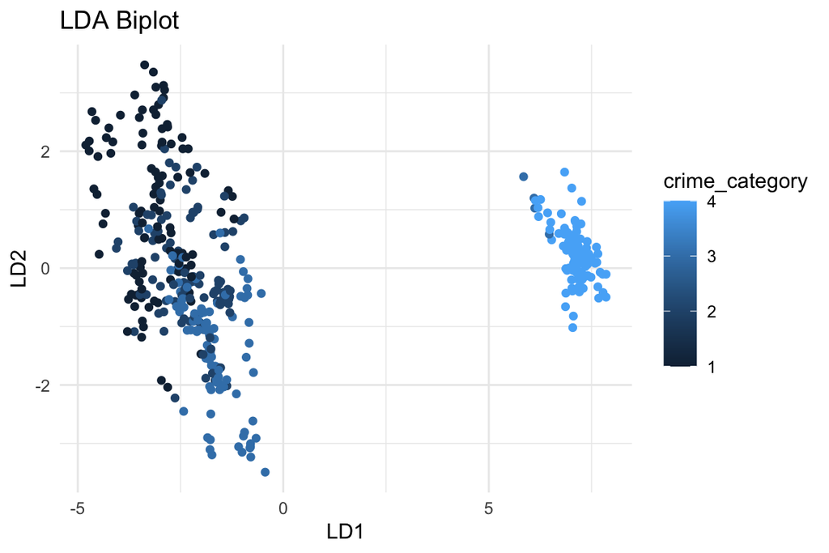

```r
library(ggplot2)

lda_model <- lda(crime_category ~ ., data = train_set)

lda_data <- data.frame(predict(lda_model, train_set)$x, crime_category = train_set$crime_category)

ggplot(lda_data, aes(x = LD1, y = LD2, color = crime_category)) +
  geom_point() +
  ggtitle("LDA Biplot") +
  xlab("LD1") +
  ylab("LD2") +
  theme_minimal()
```

#Predicting classes with he LDA model

```r
actual_crime_categories <- test_set$crime_category

test_set <- test_set[, -which(colnames(test_set) == "crime_category")]

predicted_classes <- predict(lda_model, newdata = test_set)$class

confusion_matrix <- table(actual = actual_crime_categories, predicted = predicted_classes)

print(confusion_matrix)
```

```
##       predicted
## actual  1  2  3  4
##      1  9 10  4  0
##      2  2 17  6  0
##      3  1  9 13  2
##      4  0  0  1 27
```

```r
accuracy <- sum(diag(confusion_matrix)) / sum(confusion_matrix)
cat("Overall Accuracy:", round(accuracy, 4), "\n")
```

```
## Overall Accuracy: 0.6535
```